# Analysis and Insight Report

In this project we gathered Real-world data from a variety of sources and in a variety of formats. The first file is the tweet archive of Twitter user @dog_rates, also known as WeRateDogs, an additional data from the Twitter API (JSON file) and finally the image predictions file. The quality and tidiness issues are assessed, then every issue is cleaned using define, code, test process. This is called data wrangling. The wrangling process is documented. This report communicate findings using the analysis and visualizations that we did. After exploring, analyzing the data we found that:

### The tweets amount over the time

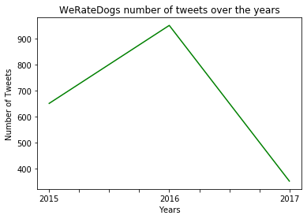

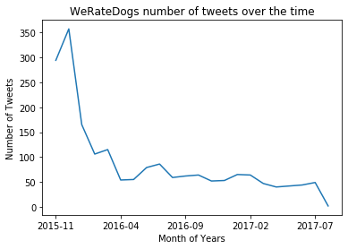

### The top twitter sources

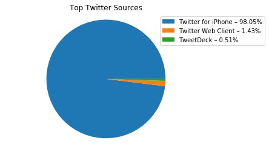

98.05% of the tweets were from Twitter for iPhone. 1.43% of the tweets are from Twitter Web Client, also, 0.51% of tweets are from TweetDeck – the least source of tweets).

### Ratings

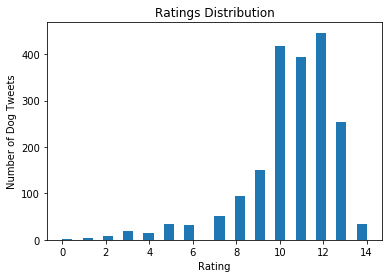

We saw the rating distribution. In over 400 tweets the rating was 12/10. 10 and 11 are close after. The average rating is 10.24.

### Top dog names

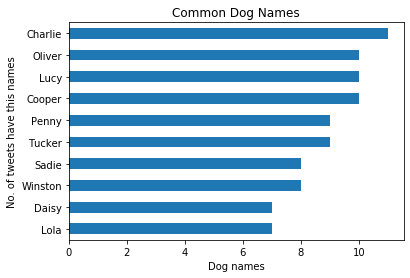

Charlie is one of the most common dog name with 11 tweets. Followed by Cooper, Lucy and Oliver.

### Common dog stage

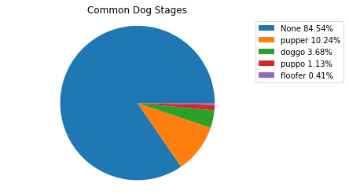

### Common breed

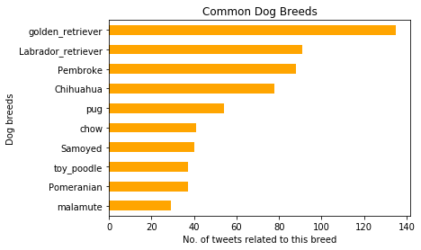

Here in the top 10 breeds, the most common breed (tweeted about) is the golden retriever with over 130 tweets. Then we have Labrador retriever with over 90 tweets followed by the Pembroke with 90 tweets.

### Top favorite tweet

Top favourite tweet: Here's a super supportive puppo participating in the Toronto #WomensMarch today. 13/10 https://t.co/nTz3FtorBc

### Top retweeted tweet

Top retweeted tweet: Here's a doggo realizing you can stand in a pool. 13/10 enlightened af (vid by Tina Conrad) https://t.co/7wE9LTEXC4

### The top favorite tweet breed

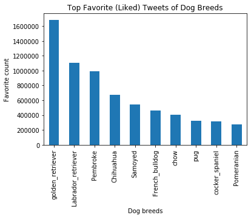

### The top re-tweeted breed

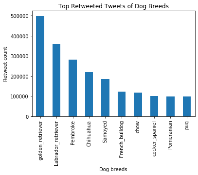

The top retweeted breed is Golden retriever with 500K of RTs! Followed by Labrador retriever with 350K RTs and Pembroke with 275K RTs.